# DATA606 Project 3

Sergio Ortega Cruz

October 20, 2018

## Harvesting Information from Indeed.com

Indded.com offered a fairly open way to harvest information, with no blockages so we started like this there are several libraries for XML and HTML processing and adding some new ones for text minig that prove to be very useful

```r
library(rvest)
library(RCurl)
library(plyr)
library(dplyr)
library(stringr)
library(tidyr)
```

```r
library(ggplot2)
library(tm)
library(wordcloud)
library(tidytext)
library(xtable)
library(readr)
library(tidytext)
library(knitr)
library(RColorBrewer)
library(SnowballC)
```

found a great function that packages a lot of the Text mining information as executes most of the outcomes of the analysis

```r
source('http://www.sthda.com/upload/rquery_wordcloud.r')
```

Then I execute the search for “Hot” cities for datascience jobs and limit the amount of hits to the source, after this generation of a dataframe to “catch” and extract the relevant information and fields

```r
#choosing "hot" cities for datascience openings
city.set <- c("New+York+NY", "Seattle+WA", "Washington+DC","Atlanta+GA","Boston+MA")

#This is the term ww will be searching
target.job <- "data+scientist"
#Indeed offer a fairly open way to harvest information the tags get confusing
base.url <- "https://www.indeed.com/"

max.results <- 50

#create a df to hold everything that we collect
jobs.data <- data.frame(matrix(ncol = 7, nrow = 0))
n <- c("city","job.title","company.name","job.location","summary.short","salary","links,summary.full")
colnames(jobs.data)<-n



#Havesting data for all the cities and begin to parse the results with xpaths to extract interesting information
for (city in city.set){
  print(paste("Downloading data for: ", city))


  for (start in range(0,max.results,10)){

    url <- paste(base.url,"jobs?q=",target.job,"&l=",city,"&start=", start ,sep="")
    page <- read_html(url)
    Sys.sleep(1)



    #get the links
    links <- page %>%
      html_nodes("div") %>%
      html_nodes(xpath = '//*[@data-tn-element="jobTitle"]') %>%
      html_attr("href")


    #get the job title
    job.title <- page %>%
      html_nodes("div") %>%
      html_nodes(xpath = '//*[@data-tn-element="jobTitle"]') %>%
      html_attr("title")

    #get the job title
    job.title <- page %>%
      html_nodes("div") %>%
      html_nodes(xpath = '//*[@data-tn-element="jobTitle"]') %>%
      html_attr("title")

    #get the company name
    company.name <- page %>%
      html_nodes("span")  %>%
      html_nodes(xpath = '//*[@class="company"]')  %>%
      html_text() %>%
      trimws -> company.name

    #get job location
    job.location <- page %>%
      html_nodes("span") %>%
      html_nodes(xpath = '//*[@class="location"]')%>%
      html_text() %>%
      trimws -> job.location

    #get the short sumary
    summary.short <- page %>%
      html_nodes("span")  %>%
      html_nodes(xpath = '//*[@class="summary"]')  %>%
      html_text() %>%
      trimws -> summary.short

  }

 #create a structure to hold our full summaries
  summary.full <- rep(NA, length(links))

  #fill in the job data
  job.city <- rep(city,length(links))

  #add a place-holder for the salary
  job.salary <- rep(0,length(links))

  #iterate over the links that we collected
  for ( n in 1:length(links) ){

    #build the link
    link <- paste(base.url,links[n],sep="")

    #pull the link
    page <- read_html(link)

    #get the full summary
    s.full <- page %>%
      html_nodes("span")  %>%
      html_nodes(xpath = '//*[@class="summary"]') %>%
      html_text() %>%
      trimws -> s.full

    #check to make sure we got some data and if so, append it.
    #as expired postings return an empty var
    if (length(s.full) > 0 ){
      summary.full[n] = s.full
    }

  }

  #add the newly collected data to the jobs.data
  jobs.data <- rbind(jobs.data,data.frame(city,
                                          job.title,
                                          company.name,
                                          job.location,
                                          summary.short,
                                          job.salary,
                                          links,
                                          summary.full))


}
```

```
## [1] "Downloading data for:  New+York+NY"
## [1] "Downloading data for:  Seattle+WA"
## [1] "Downloading data for:  Washington+DC"
## [1] "Downloading data for:  Atlanta+GA"
## [1] "Downloading data for:  Boston+MA"
```

Then write the resulting dataframe into a CSV File

```r
write.csv(jobs.data, file = "MyData.csv")
```

We start to analyze the information

This is a Worldcloud that tell us a bit of the story between soft and hard skills.

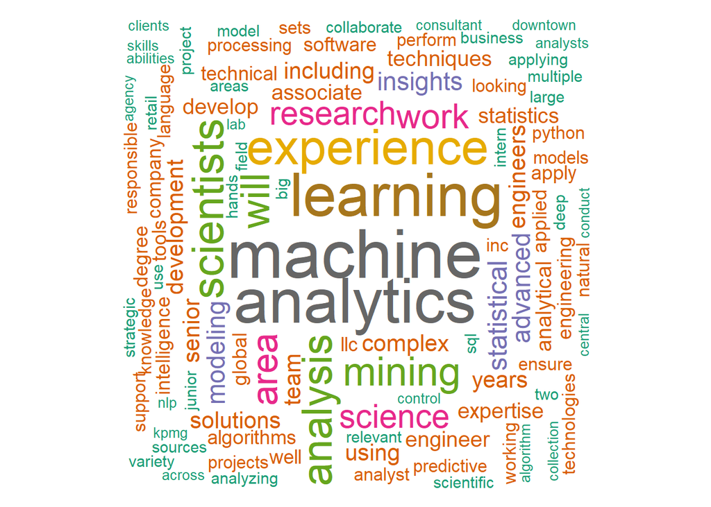

```r
#taking out exceptions of words we don't want to be part of the cloud because they're not relevant

res<-rquery.wordcloud(jobs.data, type=c("text"),
                 lang="english", excludeWords = c("new", "york", "austin","sanfrancisco", "san", "francisco","newyorkny","seattlewa","austintx","seattle","boston","data","scientist",
                                                  "atlantaga","atlanta","washingtondc","sanfranciscoca","washington","bostonma"),
                 textStemming = FALSE,  colorPalette="Dark2",
                 max.words=200)
```

Now we Show a Table showing the words mentioned with more frequency.

```r
tdm <- res$tdm
freqTable <- res$freqTable

# Show the top10 words and their frequency
head(freqTable, 10)
```

```
##                  word freq
## machine       machine   32
## analytics   analytics   29
## learning     learning   28
## experience experience   22
## scientists scientists   19
## analysis     analysis   18
## mining         mining   17
## will             will   17
## area             area   15
## work             work   14
```

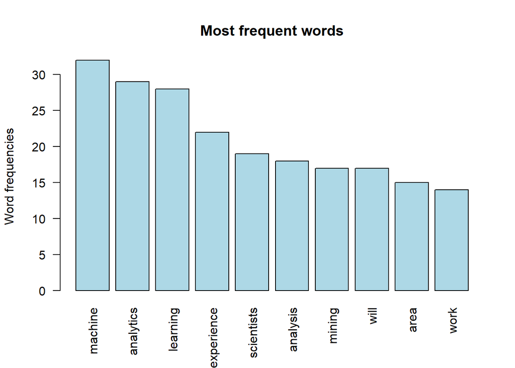

```r
# Bar plot of the frequency for the top10
barplot(freqTable[1:10,]$freq, las = 2,
        names.arg = freqTable[1:10,]$word,
        col ="lightblue", main ="Most frequent words",
        ylab = "Word frequencies")
```

Now showing frequent time concepts in the job postings and just to exemplify a method on quantify strength of terms among each other in these case “learning”"

```r
#we want to identify words that occur at least 15 times :
findFreqTerms(tdm, lowfreq = 15)
```

```
## [1] "analysis"   "analytics"  "area"       "experience" "learning"
## [6] "machine"    "mining"     "scientists" "will"
```

```r
#You could also analyze the correlation (or association) between frequent terms. The R code below identifies which words are associated with "learning"

findAssocs(tdm, terms = "learning", corlimit = 0.3)
```

[output not shown]

[output cut: 290 more lines]

[output not shown]